# 2. praktikum

11.02.2026

# Andmetüübid ja objektitüübid

## Tunnuste jagunemine

See, et andmeanalüüs on *kvantitatiivne*, ei tähenda, et kõik andmed ise peaksid tingimata olema arvulised. Laiemalt jagunevadki tunnused **kvalitatiivseteks** ja **kvantitatiivseteks**.

- **Kvalitatiivsed**/mittearvulised/kategoriaalsed:
  - **nominaalskaalal**: kaks või enam kategooriat, mis teineteist välistavad. Peetakse kõige ebatäpsemaks ja vähem informatiivseks tunnusetüübiks. Samas on just nominaalskaala tunnused humanitaar- ja sotsiaalteaduste andmestikes väga levinud.  
    Nt sugu (*mees*/*naine*/*muu*), tegusõna sihilisus (*sihiline*/*sihitu*), kääne (*nimetav*/*omastav*/*osastav*), *nimi*, *kogumispunkt*, *teema* jne.
  - **ordinaalsel e järjestusskaalal**: kategooriad on mingil alusel järjestatud, aga väärtuste vahe ei pruugi olla ühesugune.  
    Nt haridus (*alg-*/*põhi-*/*kesk-*/*kõrgharidus*), nõustumine (*ei nõustu üldse* / *pigem ei nõustu* / *pigem nõustun* / *nõustun täielikult*).
- **Kvantitatiivsed**/arvulised:
  - **intervalli- e vahemikskaalal**: esitab võrdseid erinevusi skaala punktide vahel.  
    Nt *temperatuur (Celsiuse või Fahrenheiti skaalal!)*.
  - **suhteskaalal**: nagu intervalliskaala, aga tähendusliku nullpunktiga.  
    Nt *sõnasagedused*, *sõnade graafilised/silbilised pikkused*, *reaktsiooniaeg*.
  - kvantitatiivsed tunnuseid võib jagada ka
    - **pidevateks** e mõõdetavateks (temperatuur *kraadides*, pikkus *sentimeetrites*, reaktsioon *millisekundites*, valuutakurss *dollarites*, vanus *aastates*)
    - **diskreetseteks** e loendatavateks (sõnasagedused korpuses, laste arv peres, külastajate arv etendusel).

Eri skaalal tunnused võimaldavad erineval hulgal tehteid.

- Kõige piiratumalt saab opereerida nominaalskaala tunnustega: nende väärtusi saab võrrelda ainult kvalitatiivselt (nt kass **ei ole** koer).
- Järjestusskaala tunnuste väärtuseid saab lisaks võrrelda ka sellel alusel, et mingi väärtus on **suurem/rohkem kui** mingi teine (nt keskharidus tähendab rohkem haridust kui põhiharidus, *pigem nõustun* tähendab rohkem nõustumist kui *pigem ei nõustu*).
- Intervalliskaalal tunnustega saab teha kõiki neid võrdlusi, mida nominaal- ja järjestusskaala tunnustega (nt 3 kraadi ei ole 2 kraadi ja 3 kraadi on rohkem kui 2 kraadi), ent lisaks saab öelda ka, kui palju (ehk kui mitme intervalli **võrra**) üks väärtus teisest suurem/väiksem on (nt 3 kraadi on 1 kraadi võrra rohkem kui 2 kraadi).
- Suhteskaala tunnused võimaldavad kõige rohkem tehteid. Lisaks kõikidele eelnimetatutele saab neid tunnuseid võrrelda ka sellel alusel, **kui mitu korda** on mingi väärtus teisest väärtusest suurem või väiksem (nt 80-aastane on 4 korda vanem kui 20-aastane, aga 80 kraadi ei ole 4 korda soojem kui 20 kraadi).

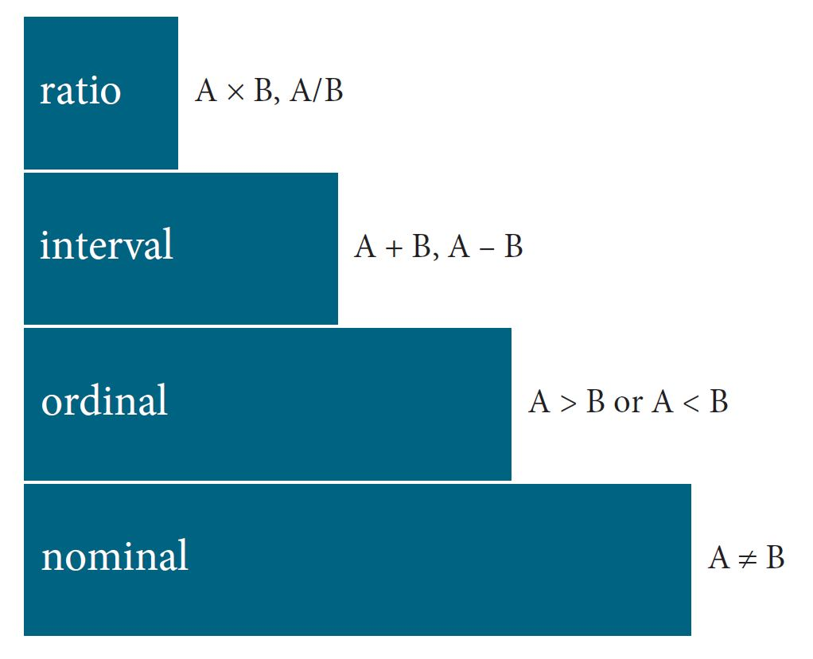

Levshina 2015: 18

Küsitluses, millele vastasid, olid järgmised küsimused. Millised neist on kvalitatiivsed ja millised kvantitatiivsed? Millisel skaalal tunnused on?

```
##
## Q2  "Mis on sinu sünniaasta?"
## Q3  "Millisel õppekaval õpid?"
## Q4  "Mitu aastat oled käinud ülikoolis?"
## Q5  "Kas sul on varasemaid kogemusi kvantitatiivsete meetoditega? "
## Q6  "Kirjelda oma programmeerimisoskusi (ükskõik mis keeles)"
## Q7  "Kui tõenäoline on, et läbid selle kursuse?"
## Q8  "Kohv või tee?"
## Q9  "Hinda oma söögitegemisoskusi"
## Q10 "Vali loom"
```

### Nominaalskaalal tunnused

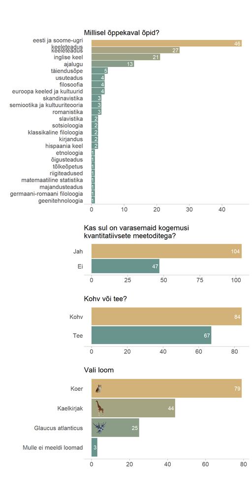

### Nominaalskaalal tunnused?

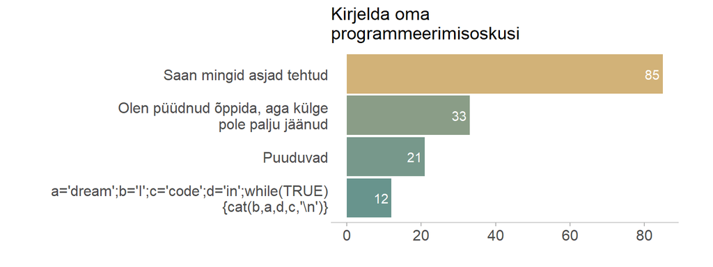

### Ordinaalskaalal tunnused

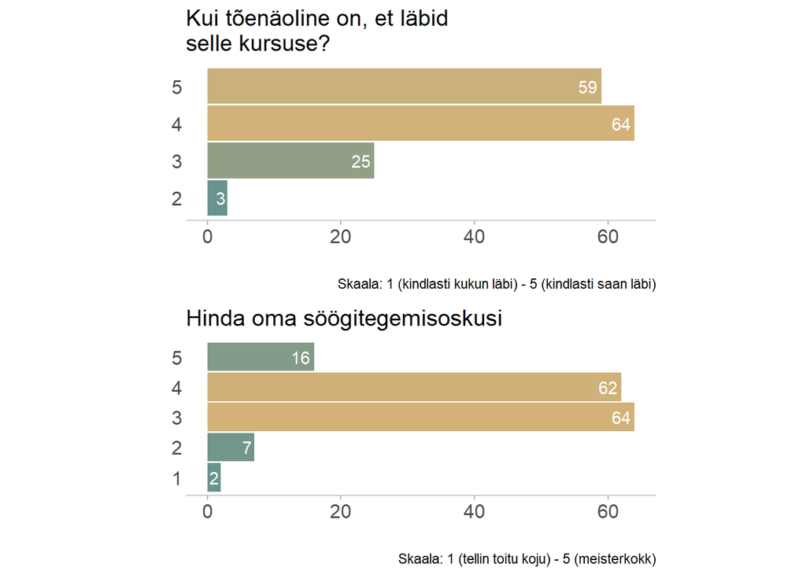

### Intervalliskaalal tunnused

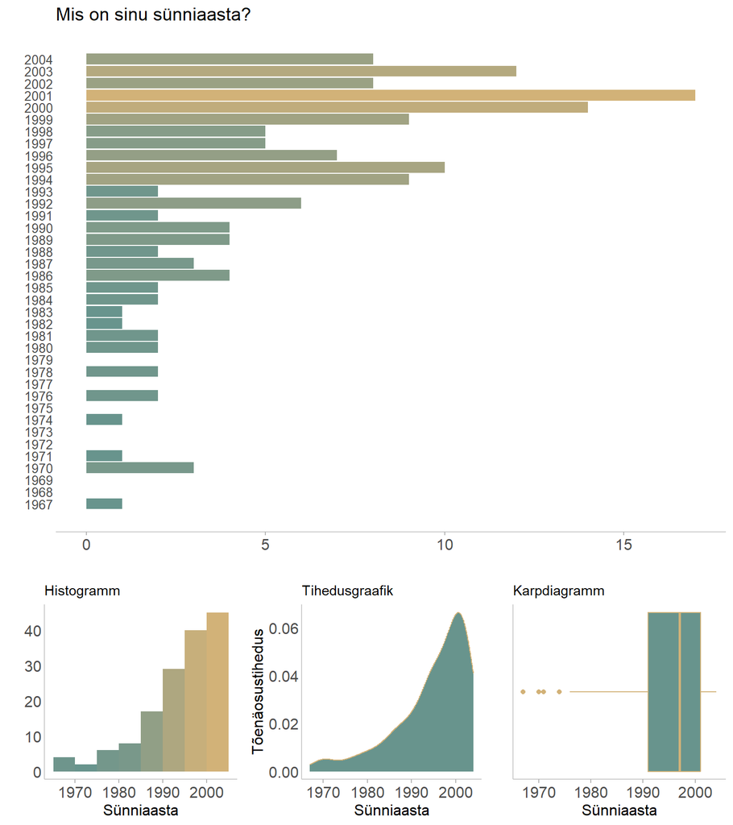

### Suhteskaalal tunnused

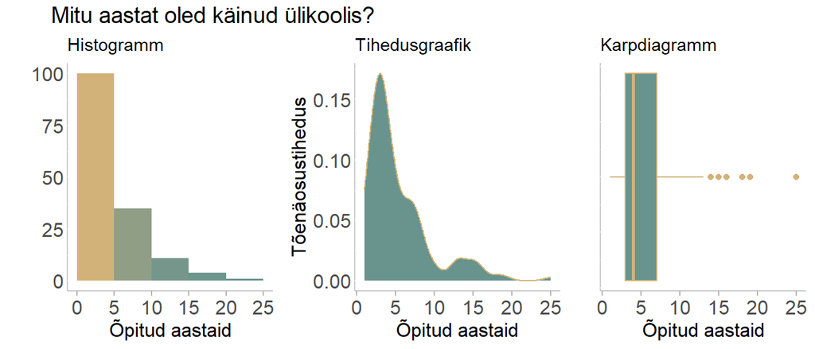

## Objektitüübid

Saame R-is töötada erinevat tüüpi andmetega. Suhte- ja intervallskaala väärtused on tüüpiliselt arvud, nominaal- ja järjestusskaala väärtused on tüüpiliselt tekst. Viimaseid tuleb R-is kirjutada jutumärkide vahele.

```r
68
```

```
## [1] 68
```

```r
1.7^1.7
```

```
## [1] 2.464695
```

```r
"kass"
```

```
## [1] "kass"
```

```r
"kass ja koer"
```

```
## [1] "kass ja koer"
```

Võime toimetada R-is niisiis küll ka konkreetsete arvude või tekstijärjenditega, aga enamasti tekib meil vajadus neid väärtusi või erinevate tehete tulemusi hilisemaks kasutamiseks talletada. **Objektiks** võimegi nimetada elementi, mis **talletab** mingit tüüpi andmeid (teksti/tekste, arve, tabeleid, maatrikseid jne). Objektile saab väärtusi omistada kas võrdusmärgiga `=` või noolekesega `<-`. Sellel kursusel eelistame noolekest, et selgemalt eristada objektidele ja funktsiooni argumentidele väärtuste omistamist.

```r
a <- 1.7

68 -> b # noolekese ots peab olema suunatud objekti suunas
68 <- b # ei tööta
```

```
## Error in 68 <- b: invalid (do_set) left-hand side to assignment
```

```r
c <- b/(a^2)
d <- "kass"
```

Kui omistame mingile objektile väärtuse, ilmub objekt R-i keskkonda (*Environment* paneeli), aga väärtust konsooli ei trükita. Konsooli trükkimiseks saab kasutada nüüd lihtsalt objekti nime.

```r
c
```

```
## [1] 23.52941
```

Objektide kasutamine teeb esiteks meie koodi paremini loetavaks, kuna objektidele saab anda tähenduslikke nimesid. Piiranguks nimetamisel on vaid see, et **objekti nimi ei tohi alata numbriga ega tohi sisaldada tühikuid ega kirjavahemärke peale alakriipsu ja punkti**.

```r
pikkus_m <- 1.7 # loome objekti, mille väärtus on 1.7
kaal_kg <- 68 # loome objekti, mille väärtus on 68

KMI <- kaal_kg/(pikkus_m ^ 2) # loome objekti, mille väärtus on objekti 'kaal_kg' väärtus jagatud objekti 'pikkus_m' väärtuse ruuduga
KMI # trükime objekti 'KMI' väärtuse konsooli
```

```
## [1] 23.52941
```

Teiseks saab üht ja sama objekti koodis korduvalt kasutada ja selle väärtusi (nt vastavalt kasutaja sisendile) muuta. Sellest saab paremini aru, kui hakkame andmetabelitega tegelema.

Igat objekti iseloomustavad **tüüp** ja **klass**.

**Objektitüüp** (vahel nimetatakse ka andmetüübiks) ütlebki meile seda, **mis sorti** andmetega on tegemist. Põhilised objektitüübid on R-is niisiis

- **arv** (*numeric*)  
  nt `123.456` või `1234`
- **tekst** (*character*)  
  nt `"Tere!"`, `"Number 2"`, `"123.456"`
- **tõeväärtus** (*logical*)  
  nt `TRUE` ja `FALSE`

### Arvud

**Arvud** (*numeric*), nagu oleme juba näinud, kirjutatakse lihtsalt numbritega. Arvulise väärtusega muutujatega saab teha matemaatilisi tehteid (liita-lahutada jne).

```r
4 # see trükitakse välja, objekti ei teki
```

```
## [1] 4
```

```r
arv1 <- 4 # objektile 'arv1' omistatakse väärtus 4, aga midagi välja ei trükita
arv2 <- 5

arv3 <- sqrt((arv1 + arv2)^3) # ^-märk tähistab siin astendamist, sqrt() on ruutjuure leidmise funktsioon
arv3 # see trükitakse välja
```

```
## [1] 27
```

Arvud võivad omakorda jaguneda täisarvudeks (`integer`) ja murdarvudeks/ujukomaarvudeks (`double`). Murdarvus kasutatakse R-is vaikimisi koma asemel punkti (nt `2.7`, mitte `2,7`)!

### Tekst

**Tekst** (*character*) tuleb kirjutada jutumärkides (kas ühe- või kahekordsetes). Ka numbreid võib esitada tekstina. Tekstiga matemaatilisi tehteid teha ei saa, küll aga saab eri funktsioonide abil näiteks tekstiosi omavahel kombineerida või tekstijada (ingl *string*) pikkust pärida.

```r
"Tartu" # see trükitakse konsooli, objekti ei teki
```

```
## [1] "Tartu"
```

```r
pärisnimi <- "Tartu" # objektile 'pärisnimi' omistatakse väärtus "Tartu", aga midagi välja ei trükita
üldnimi <- 'ülikool' # ühekordsed jutumärgid töötavad samaväärselt
arv <- "394" # objektile 'arv' omistatakse tekstiväärtus "394"
paste(pärisnimi, üldnimi, arv, sep= " ") # kleebime kolme objekti väärtused kokku (paste = kleebi)
```

```
## [1] "Tartu ülikool 394"
```

```r
nchar(üldnimi) # leia objekti 'üldnimi' väärtuse tähemärkide arv (n = number, char = characters)
```

```
## [1] 7
```

```r
substr(üldnimi, 4, 7) # võta välja objekti üldnimi väärtuse 4.-7. tähemärk (substr = substring)
```

```
## [1] "kool"
```

```r
# mis juhtub tekstiga matemaatilisi tehteid proovides?
pärisnimi + üldnimi
```

```
## Error in pärisnimi + üldnimi: non-numeric argument to binary operator
```

```r
arv^2
```

```
## Error in arv^2: non-numeric argument to binary operator
```

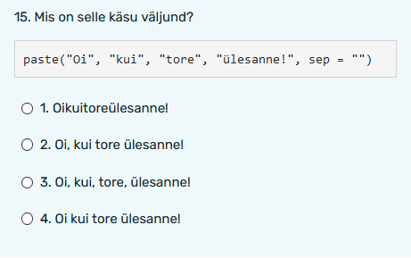

Küsimus R-i testist

### Tõeväärtused

**Tõeväärtus** (*logical*) on binaarne muutuja, millel on kaks võimalikku väärtust: **TRUE** ja **FALSE**, need sisestatakse suurtäheliselt ilma jutumärkideta, töötab ka ainult esitähega T/F.

Milleks tõeväärtusi vaja on?

Tõeväärtused saame vastuseks, kui testime, kas mingi tingimus on täidetud. Tingimuste kontrolli läheb meil vaja siis, kui meil on näiteks suuremast andmestikust vaja leida kindlatele tunnustele vastav alamosa (näiteks võtta tabelist välja ainult read, kus tulbas `Sugu` on väärtus *mees*, või read, kus tulbas `Vanus` on suurem väärtus kui 50). Tõeväärtustega saab ka matemaatilisi tehteid teha.

```r
üks <- 1 # objektile 'üks' omistatakse väärtus 1, midagi välja ei trükita
kaks <- 2
üks > kaks # Kas objekti 'üks' väärtus on suurem kui objekti 'kaks' väärtus?
```

```
## [1] FALSE
```

```r
3 == üks + kaks # Kas arv 3 võrdub objekti 'üks' väärtuse ja objekti 'kaks' väärtuse summaga?
```

```
## [1] TRUE
```

```r
"koer" == "kass" # Kas tekst "koer" on sama mis "kass"?
```

```
## [1] FALSE
```

```r
TRUE == 1 # Kas TRUE on võrdne ühega?
```

```
## [1] TRUE
```

```r
FALSE == 0 # Kas FALSE on võrdne nulliga?
```

```
## [1] TRUE
```

```r
FALSE + TRUE + FALSE
```

```
## [1] 1
```

```r
400 * TRUE
```

```
## [1] 400
```

### Tundmatu väärtus

Lisaks on R-is oluline **tundmatu väärtus** ehk **NA** (*not applicable*, *not available*, *no answer*). Kõigi objektitüüpide hulgas võib olla tundmatuid väärtusi, näiteks kui me ei tea kõikide oma andmestiku katseisikute vanuseid, mõni mõõtmistulemus on läinud untsu või mõni kategooria pole üldse kõikide vaatluste puhul relevantne. Tundmatu väärtusega tehteid tehes on tulemuseks samuti tundmatu väärtus.

```r
tundmatu <- NA
3 + NA
```

```
## [1] NA
```

```r
is.na(tundmatu)
```

```
## [1] TRUE
```

### Objekti tüübi küsimine

Objektide tüüpi saab küsida käsuga **`mode()`** või **`class()`**.

```r
mode(arv1)
```

```
## [1] "numeric"
```

```r
class(arv1)
```

```
## [1] "numeric"
```

```r
mode(pärisnimi)
```

```
## [1] "character"
```

```r
class(pärisnimi)
```

```
## [1] "character"
```

```r
mode(tundmatu)
```

```
## [1] "logical"
```

```r
class(tundmatu)
```

```
## [1] "logical"
```

Samuti võib küsida, kas objekt on mingit konkreetset tüüpi.

```r
is.numeric(arv1)
```

```
## [1] TRUE
```

```r
is.character(pärisnimi)
```

```
## [1] TRUE
```

```r
is.logical(tundmatu)
```

```
## [1] TRUE
```

Vahel kodeeritakse andmestikes tundmatud väärtused mingi kindla väärtuse abil, nt `-99`, `.` vmt. Sel juhul ei tea R vaikimisi, et tegemist on erilise väärtusega, ning seda tuleb andmeid sisse lugedes talle eraldi öelda.

## Ülesanne 1

Loo üks objekt `nimi`, millele omistad väärtuseks oma eesnime, teine objekt `vanus`, millele omistad väärtuseks oma vanuse, ning kolmas objekt `hinnang`, mis võib saada väärtuseks ainult kas sõna *juba* või sõna *alles*.

Jooksuta seejärel allolevat `paste()` käsku, et lasta R-il sind sobivalt tutvustada.

```r
paste("Minu nimi on ", nimi, " ja ma olen ", hinnang, " ", vanus, "-aastane!", sep = "")
```

## Objektiklassid

**Objektiklass** tähistab andmestruktuuri ehk seda, kuidas andmed objektis on **korrastatud**. Objektiklasse on küll ka rohkem ja spetsiifilisemaid, aga esialgu võiks meil tulla tegemist 4 põhilise klassiga:

- **vektorid** (*vector*)  
  nt `1`, `1:10`, `c(1:10)`, `c(1,400,800)`, `"Tere!"`, `c("Tere!", "Head aega!")`, `TRUE`, `c(TRUE, FALSE, TRUE, TRUE)`, `vector("character", length = 10)`
- **listid** (*list*)  
  nt `list(1:10)`, `list(1:10, 10:5)`, `list(1:10, "a", list(c(TRUE, FALSE), TRUE))`
- **maatriksid** (*matrix*)  
  nt `matrix(1:9)`, `matrix(1:9, nrow = 3)`, `matrix(c(TRUE, TRUE, FALSE, FALSE), ncol = 2)`
- **tabelid** (*data.frame*)  
  nt `data.frame(nimi = c("Anu", "Mart", "Sipsik"), pikkus = c(145, 160, 30), kaal = c(40, 58, 2))`, `as.data.frame(matrix(1:9, nrow = 3))`

**VEKTORID** on ühemõõtmelised objektid, mis võivad sisaldada **ainult üht tüüpi** elemente, nt ainult arve, ainult teksti või ainult tõeväärtuseid.  
**MAATRIKSID** on kahemõõtmelised (= ridade ja tulpadega) objektid, mis võivad sisaldada **ainult üht tüüpi** elemente, nt ainult arve, ainult teksti või ainult tõeväärtuseid.  
**TABELID** on kahemõõtmelised objektid, mis võivad veergudes sisaldada **erinevat tüüpi** elemente (nt tekstivektoreid, arvuvektoreid, tõeväärtusvektoreid).  
**LISTID** on komplekssed, struktureerimata objektid, mis võivad sisaldada **erinevat tüüpi** elemente, sh tabeleid ja teisi liste, funktsioone jm.

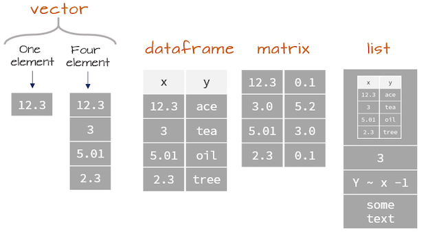

R-i objektiklassid (https://web.itu.edu.tr/~tokerem/r_language.html)

Kõige rohkem pöörame sellel kursusel tähelepanu just vektoritele ja tabelitele. Tabelite (ja maatriksite) puhul on oluline ära märkida, et R-is peaks tabel olema kindlasti **sümmeetriline**, st igas reas on ühepalju tulpasid ja igas tulbas ühepalju ridu (nn *tidy* andmestruktuur). Selline Exceli-tüüpi tabel, kus ühe ruudulise lehe peal võib olla mitu tabelit, on R-ile raskesti seeditav. Ka erinevad stiliseeritud ja pesastatud tabelid, kus ühes lahtris toimub omakorda jagunemine väiksemateks lahtriteks, võivad tekitada omajagu tüli (vt ka nt [https://www.r-bloggers.com/2020/05/what-it-takes-to-tidy-census-data/](https://www.r-bloggers.com/2020/05/what-it-takes-to-tidy-census-data/?fbclid=IwAR1uOsWBZw2Vuq-mIWuo-epZ9x_1E0i2hlLtY967J3hh3f3ZCRbrrM0vuGg)).  
Keerulisema struktuuriga objektidega, nagu on R-is list, me täna ei tegele, aga näeme neid rohkem siis, kui hakkame mudelite väljundeid vaatama.

### Vektorid

R-i põhiline objektiklass on **vektor**. Kõik teised objektid koosnevad vektoritest, st nende osi saab käsitleda vektoritena.

Vektor on ühemõõtmeline objekt, millel võib olla üks või enam üht tüüpi väärtust. Kõige lihtsam vektor koosnebki ainult ühest elemendist, st tal on üks väärtus. Näiteks kui sisestada üks arv või üks sõna, siis see on vektor, millel on üks element.

```r
4
```

```
## [1] 4
```

```r
length(4) # käsk `length()` annab vastuseks vektori elementide arvu.
```

```
## [1] 1
```

Vektoris võib olla ka rohkem kui üks väärtus. Funktsioon **`c()`** (*concatenate*) kombineerib üksikud väärtused kokku vektoriks (erinevate väärtuste loendiks).

```r
arvuvektor <- c(3,6,8,11,24)
tekstivektor <- c("nina", "kõrvad", "silmad")
```

Järjestikuste arvude jada saab luua ka kooloniga.

```r
arvuvektor2 <- c(1,2,3,4,5)
# on sama, mis
arvuvektor3 <- 1:5
```

Kui mõelda pisut etteruttavalt andmetabelite peale, siis põhimõtteliselt iga andmetabeli tulp, mis sisaldab üksikute vaatluste konkreetse tunnuse väärtusi (nt vanuseid), on sisuliselt üks vektor.

**Proovi nüüd loodud vektorite peal funktsiooni `length()`, mis ütleb, mitu väärtust vektoris on.**

Ühes vektoris on **kõik elemendid sama tüüpi** (nt ainult arvud, ainult tekst, ainult loogilised väärtused). Vektori tüüpi saab jällegi küsida käsuga `mode()` või `class()`.

```r
class(arvuvektor)
```

```
## [1] "numeric"
```

Kui püüda samasse vektorisse kokku panna eri tüüpe elemente, siis arvude ja loogiliste väärtuste kombineerimisel teisendatakse loogilised väärtused arvudeks (0 või 1), nende kombineerimisel tekstiga omakorda teisendatakse kõik elemendid tekstiks.

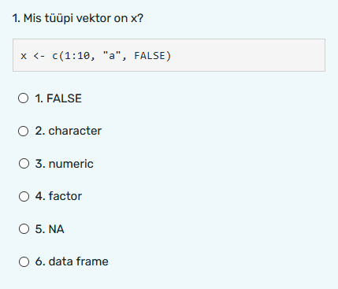

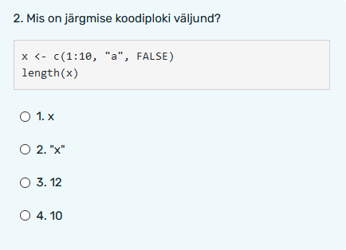

Küsimused R-i testist

[figure not shown]

Käsk `c()` võib omavahel kokku kombineerida mitte ainult mitu üksikut väärtust, vaid ka mitu mitmest elemendist koosnevat vektorit.

```r
veel_üks_arvuvektor <- c(arvuvektor, arvuvektor2, 20:30)
veel_üks_arvuvektor
```

```
##  [1]  3  6  8 11 24  1  2  3  4  5 20 21 22 23 24 25 26 27 28 29 30
```

```r
length(veel_üks_arvuvektor)
```

```
## [1] 21
```

Vektoritega tehete tegemisel rakendatakse tehet (nt liitmine) elementide kaupa. Kui vektorid on eri pikkusega, siis lühemat vektorit taaskasutatakse.

```r
# ühepikkused vektorid
arvuvektor + arvuvektor2 # liida 3+1, 6+2, 8+3, 11+4, 24+5
```

```
## [1]  4  8 11 15 29
```

```r
# erineva pikkusega vektorid
1:10 * c(3,0) # 1*3, 2*0, 3*3, 4*0 jne
```

```
##  [1]  3  0  9  0 15  0 21  0 27  0
```

```r
1:10 * c(3,0,1) # 1*3, 2*0, 3*1 ... 10*3
```

```
##  [1]  3  0  3 12  0  6 21  0  9 30
```

Vektorist saab üksiku väärtuse või mingi osa kätte **indeksite** abil. Indeksid on tegelikult ise ka vektorid. Indeks kirjutatakse vektori nime järele nurksulgudesse:

```r
tekstivektor2 <- c("kala", "kana", "kaja", "kava", "kaba", "kada", "kaka", "kaua", "kama")
tekstivektor2[3] # vektori kolmas element
```

```
## [1] "kaja"
```

```r
tekstivektor2[2:4] # vektori teine, kolmas ja neljas element
```

```
## [1] "kana" "kaja" "kava"
```

```r
tekstivektor2[c(5,1)] # vektori viies ja esimene element
```

```
## [1] "kaba" "kala"
```

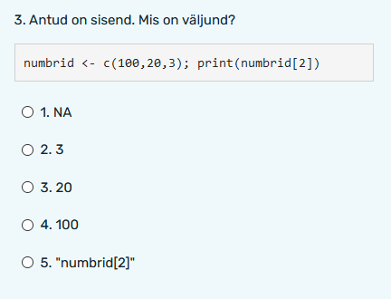

Küsimus R-i testist

Omamoodi indeksitena saab kasutada ka võrratusi, mispuhul indeksitena kasutatav vektor on tõeväärtuste vektor.

```r
tekstivektor2 == "kana" # küsi iga tekstivektori elemendi kohta, kas see võrdub sõnaga "kana"
```

```
## [1] FALSE  TRUE FALSE FALSE FALSE FALSE FALSE FALSE FALSE
```

```r
tekstivektor2[tekstivektor2 == "kana"] # küsi vektorist ainult neid elemente, mis võrduvad sõnaga "kana"
```

```
## [1] "kana"
```

```r
arvuvektor > 10 # küsi iga arvuvektori elemendi kohta, kas see on suurem kui 10
```

```
## [1] FALSE FALSE FALSE  TRUE  TRUE
```

```r
arvuvektor[arvuvektor > 10] # küsi vektorist ainult neid elemente, mis on suuremad kui 10
```

```
## [1] 11 24
```

Vektori eritüüp on faktor. **Faktor** (*factor*) on piiratud hulga väärtustega nominaalne vektor.

```r
vanus <- factor(c("vana","noor","noor"), levels=c("noor","vana"))
```

Miks faktoreid vaja on?  
1) faktori väärtuseid saab järjestada, see on oluline näiteks järjestusskaalaga muutujate puhul (“vana” > “keskealine” > “noor”);  
2) on arvutuslikult ökonoomsem, sest ehkki faktori taseme (*level*) nimi võib koosneda mitmest tähemärgist (nt *noor*, *keskealine*), on iga tase/klass tegelikult kodeeritud unikaalse arvuga (nt *1*, *2*).

Faktori tasemed märgivad faktori unikaalseid väärtusi. Faktori tasemed on alati mingil moel järjestatud, ent vaikimisi tähestiku järjekorras või arvude puhul väiksemast suuremani. Faktori tasemeid saab küsida käsuga `levels()`.

```r
haridus <- factor(c("põhi", "kesk", "põhi", "kesk", "kõrg"))
arvud <- factor(c(9,3,6,2,1,1,2,2))
levels(haridus)
```

```
## [1] "kesk" "kõrg" "põhi"
```

```r
levels(arvud)
```

```
## [1] "1" "2" "3" "6" "9"
```

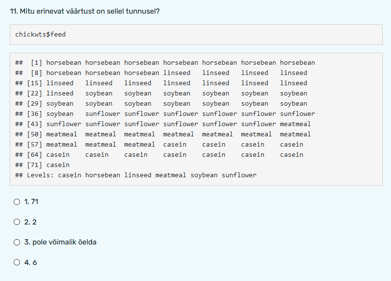

Küsimus R-i testist

Faktoreid saab ümber järjestada näiteks `factor()`-funktsioonis argumendi `levels` abil.

```r
haridus <- factor(haridus, levels = c("põhi", "kesk", "kõrg"))
arvud <- factor(arvud, levels = c(9,6,3,2,1))
levels(haridus)
```

```
## [1] "põhi" "kesk" "kõrg"
```

```r
levels(arvud)
```

```
## [1] "9" "6" "3" "2" "1"
```

Kui vektorite puhul annavad käsud `mode()` ja `class()` sama väljundi, siis keerukamate andmestruktuuride puhul näeme nende kasutuses juba erinevusi. Näiteks faktorite puhul ütleb `class()` seda, milline on andmestruktuur, `mode()` aga seda, mis tüüpi andmetest see struktuur koosneb.

```r
class(haridus)
```

```
## [1] "factor"
```

```r
mode(haridus)
```

```
## [1] "numeric"
```

Eraldi faktori liik on järjestatud faktor (*ordered factor*), mille puhul on eksplitsiitne ka see, et iga järgmine faktori tase on eelmisest suurem/kõrgem/rohkem/tähtsam.

```r
haridus <- factor(haridus, ordered = TRUE)
haridus
```

```
## [1] põhi kesk põhi kesk kõrg
## Levels: põhi < kesk < kõrg
```

```r
class(haridus)
```

```
## [1] "ordered" "factor"
```

```r
mode(haridus)
```

```
## [1] "numeric"
```

### Tabelid

Tabel on kahemõõtmeline objekt: on read ja veerud, aga oluline on see, et **igas reas on sama palju veerge ja vastupidi**, ehkki lahtrites võib olla ka puuduvaid väärtusi.

Siin kursusel kasutame kõige rohkem tabeleid, mille klass on *data.frame*, mingites olukordades ka maatriksit (*matrix*). Maatriksi ja *data.frame*’i vahe R-is on see, et maatriksis saab olla ainult ühte tüüpi andmeid (nt ainult arvud), aga *data.frame*’is võib iga tulp olla erinevat tüüpi.

```r
matrix(20:28, # arvud, mis tabelisse lähevad
       ncol = 3, # tulpade arv, millesse arvud jagatakse
       dimnames = list(c("1", "2", "3"), # reanimed
                       c("Arvud1", "Arvud2", "Arvud3"))) # tulbanimed
```

```
##   Arvud1 Arvud2 Arvud3
## 1     20     23     26
## 2     21     24     27
## 3     22     25     28
```

```r
data.frame(Arvud = c(20,21,22), # esimese tulba nimi ja väärtused
           Tekst = c("a", "b", "c"), # teise tulba nimi ja väärtused
           Tõeväärtused = c(TRUE, FALSE, FALSE)) # kolmanda tulba nimi ja väärtused
```

```
##   Arvud Tekst Tõeväärtused
## 1    20     a         TRUE
## 2    21     b        FALSE
## 3    22     c        FALSE
```

Nagu näeme, saab R-is andmeid ka vektoritest `data.frame()` käsuga tabeliks kokku panna, aga üldjuhul saame *data.frame*’i kujulise objekti nii, et loeme tabelina struktureeritud andmeid mingist failist.

Kui andmestik on R-is korrastatud ja **RData** formaadis salvestatud, siis neid andmestikke saab avada käsuga **`load()`**. Näiteks sellisel kujul on Moodle’is failis *kysimustik_2026.RData* korrastatud vastused küsimustikule, mida eelmises praktikumis täitsite. Lisaks on seal ka varasemate aastate vastused. Laadige RData andmestik alla ja pange see oma kursuse andmestike kausta (nt kausta nimega `andmestikud`, `andmed`, `data` vmt), **muutke vastavalt ära ka faili teekonna nimi** (nt `andmestikud/kysimustik_2026.RData`, `andmed/kysimustik_2026.RData`, `data/kysimustik_2026.RData`).

```r
load("data/kysimustik_2026.RData")
```

Selle käsurea rakendamisest justkui ei juhtugi midagi, aga töölauale tekkis objekt nimega **kysimustik**, mille klassiks on `data.frame`.

```r
class(kysimustik)
```

```
## [1] "data.frame"
```

Nüüd oleks vaja saada natuke aimu, mida see tabel endast kujutab. Selleks proovime käske/funktsioone:

- **`dim()`**
- **`View()`**
- **`head()`**
- **`tail()`**
- **`summary()`**
- **`str()`**

```r
dim(kysimustik) # mitu rida ja mitu tulpa on tabelis?
View(kysimustik) # vaata tervet andmetabelit
head(kysimustik) # näita tabeli esimesi ridu
tail(kysimustik) # näita tabeli viimaseid ridu
summary(kysimustik) # näita ülevaadet tabeli tunnustest
str(kysimustik) # näita tabeli struktuuri
```

Kui andmetabel ei ole RData-formaadis (enamasti ei ole), saab selle sisselugemiseks kasutada paljusid muid funktsioone, mis algavad üldjuhul sõnaga **`read`**.

**csv**- või **txt**-formaadis tabeleid saab lugeda näiteks järgmiste käskudega, mis erinevad põhiliselt selle poolest, millised on erinevate argumentide (nt `header`, `sep`) vaikeväärtused:

```r
kysimustik_csv <- read.table("data/kysimustik_2026.csv", header = TRUE, sep = "\t", encoding = "UTF-8")
kysimustik_csv <- read.delim("data/kysimustik_2026.csv", encoding = "UTF-8")
kysimustik_csv <- read.csv("data/kysimustik_2026.csv", sep = "\t", encoding = "UTF-8")
kysimustik_csv <- read.csv2("data/kysimustik_2026.csv", sep = "\t", encoding = "UTF-8")
```

Failil `kysimustik_2026.csv` on tulbanimedega päis (`header`), tulpasid eraldavad tabulaatorid (`\t`) ning faili kodeering on UTF-8. Kuna funktsioonide vaikeväärtused on erinevad (näiteks `read.table()` eeldab vaikimisi, et tabelil ei ole tulbanimesid), peame eri funktsioonidega andmeid sisse lugedes täpsustama erinevaid asju, vastavalt oma andmestiku struktuurile.

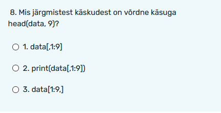

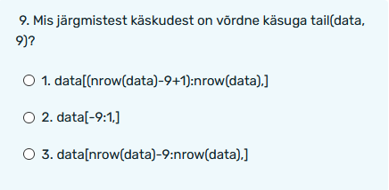

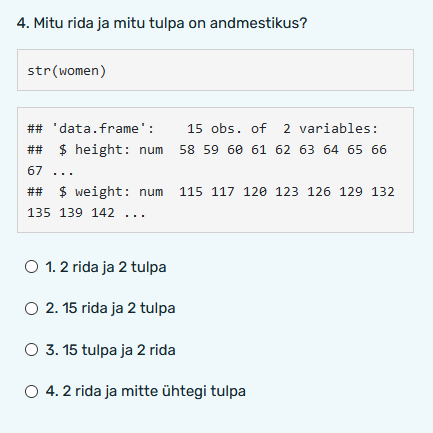

Küsimused R-i testist

R-i saab erinevate pakettide abil laadida ka muus formaadis faile, näiteks Exceli, SPSSi, SASi, STATA, JSONi või XMLi faile.

```r
# Exceli failid
# install.packages("readxl")
library(readxl)
kysimustik_xlsx <- read_excel("data/kysimustik_2026.xlsx")
```

```r
# SPSSi, SASi, STATA failid
# install.packages("haven")
library(haven)
kysimustik_sav <- read_sav("data/kysimustik_2026.sav") # SPSS
kysimustik_sas7bdat <- read_sas("data/kysimustik_2026.sas7bdat") # SAS
kysimustik_dta <- read_stata("data/kysimustik_2026.dta") # STATA
```

```r
# JSONi fail
# install.packages("jsonlite")
library(jsonlite)
kysimustik_json <- fromJSON("data/kysimustik_2026.json")
```

```r
# XMLi fail
# install.packages("xml2")
library(xml2)
kysimustik_xml <- as.data.frame(read_xml("data/kysimustik_2026.xml"))
```

Tabelist saab selle osi pärida samamoodi *indeksite* abil nagu vektorist, aga nüüd peab arvestama, et nurksulgudes tuleb märkida **nii ridade kui ka veergude indeksid**.  
**Ridade indekseid täpsustame kantsulgude sees enne koma ja tulpade indekseid pärast koma.**

```r
kysimustik[1,] # küsimustiku 1. rida
kysimustik[c(1,3,5,7),] # küsimustiku 1., 3., 5. ja 7. rida

kysimustik[,5] # küsimustiku 5. tulp
kysimustik[,1:2] # küsimustiku 1. ja 2. tulp

kysimustik[3, 5] # küsimustiku 3. rea 5. tulba väärtus
kysimustik[1:10, 5] # küsimustiku esimese 10 rea 5. tulba väärtused
```

Kui me tahame tabelist **tulbanime järgi** välja võtta ühe terve tulba, siis seda saab ka nii:

```r
kysimustik$lemmikjook
```

```
##   [1] Kohv Kohv Kohv Kohv Kohv Kohv Tee  Tee  Kohv Kohv Tee  Tee  Tee  Tee  Tee
##  [16] Tee  Kohv Tee  Tee  Kohv Tee  Kohv Kohv Tee  Kohv Tee  Kohv Tee  Tee  Tee
##  [31] Tee  Tee  Kohv Tee  Kohv Tee  Kohv Tee  Kohv Kohv Kohv Tee  Kohv Kohv Tee
##  [46] Tee  Kohv Kohv Kohv Kohv Tee  Tee  Kohv Tee  Kohv Kohv Kohv Tee  Kohv Kohv
##  [61] Kohv Kohv Tee  Tee  Kohv Kohv Tee  Kohv Kohv Kohv Kohv Kohv Kohv Tee  Kohv
##  [76] Kohv Kohv Kohv Kohv Kohv Tee  Kohv Tee  Kohv Kohv Tee  Kohv Kohv Tee  Kohv
##  [91] Kohv Tee  Tee  Tee  Kohv Tee  Kohv Kohv Tee  Kohv Tee  Kohv Tee  Kohv Kohv
## [106] Kohv Kohv Kohv Tee  Kohv Tee  Tee  Kohv Tee  Kohv Tee  Tee  Kohv Tee  Kohv
## [121] Tee  Tee  Kohv Kohv Tee  Tee  Tee  Kohv Kohv Tee  Tee  Kohv Tee  Kohv Kohv
## [136] Tee  Kohv Kohv Kohv Tee  Tee  Kohv Kohv Kohv Tee  Tee  Tee  Tee  Kohv Tee
## [151] Tee
## Levels: Kohv Tee
```

```r
# või
kysimustik[,"lemmikjook"]
```

```
##   [1] Kohv Kohv Kohv Kohv Kohv Kohv Tee  Tee  Kohv Kohv Tee  Tee  Tee  Tee  Tee
##  [16] Tee  Kohv Tee  Tee  Kohv Tee  Kohv Kohv Tee  Kohv Tee  Kohv Tee  Tee  Tee
##  [31] Tee  Tee  Kohv Tee  Kohv Tee  Kohv Tee  Kohv Kohv Kohv Tee  Kohv Kohv Tee
##  [46] Tee  Kohv Kohv Kohv Kohv Tee  Tee  Kohv Tee  Kohv Kohv Kohv Tee  Kohv Kohv
##  [61] Kohv Kohv Tee  Tee  Kohv Kohv Tee  Kohv Kohv Kohv Kohv Kohv Kohv Tee  Kohv
##  [76] Kohv Kohv Kohv Kohv Kohv Tee  Kohv Tee  Kohv Kohv Tee  Kohv Kohv Tee  Kohv
##  [91] Kohv Tee  Tee  Tee  Kohv Tee  Kohv Kohv Tee  Kohv Tee  Kohv Tee  Kohv Kohv
## [106] Kohv Kohv Kohv Tee  Kohv Tee  Tee  Kohv Tee  Kohv Tee  Tee  Kohv Tee  Kohv
## [121] Tee  Tee  Kohv Kohv Tee  Tee  Tee  Kohv Kohv Tee  Tee  Kohv Tee  Kohv Kohv
## [136] Tee  Kohv Kohv Kohv Tee  Tee  Kohv Kohv Kohv Tee  Tee  Tee  Tee  Kohv Tee
## [151] Tee
## Levels: Kohv Tee
```

See üks tulp on tegelikult ka vektor. Tulba või üksikud väärtused saab suunata ka eraldi uude objekti, tulba väärtusi omakorda indeksite abil välja võtta jne.

Nii nagu vektoreid võib ka tabelitest elemente (ridu või tulpasid) välja võtta ka võrratuste abil.

```r
# tabel
kysimustik[kysimustik$synniaasta > 2002,] # read, kus sünniaasta väärtus on suurem kui 2002
```

```
##     synniaasta                        oppekava kaua_opid kogemused_kvant
## 83        2003                    inglise keel         3             Jah
## 105       2003                 skandinavistika         2             Jah
## 112       2003                    inglise keel         3             Jah
## 114       2003 eesti ja soome-ugri keeleteadus         2             Jah
## 117       2003                    inglise keel         3              Ei
## 119       2003                     romanistika         3             Jah
## 121       2003                    inglise keel         3             Jah
## 123       2003                    inglise keel         3             Jah
## 124       2004                     romanistika         1              Ei
## 132       2003                     keeleteadus         3             Jah
## 133       2003                      slavistika         1              Ei
## 135       2004                      slavistika         2              Ei
## 137       2004                    inglise keel         3             Jah
## 138       2004                    inglise keel         3              Ei
```

[output cut: 48 more lines]

```r
# vektor
kysimustik[kysimustik$kogemused_kvant == "Jah",]$kaua_opid # "kaua_opid" tulba väärtused ridadel, kus "kogemused_kvant" väärtus on "Jah"
```

```
##   [1] 10  6  5 25  9  4  6  4  5  8 12  1  4  7  8  6 15  7 10  4 16  3  5  5 13
##  [26]  8  2  2  1  2  3 13  3  1  7  1  5  3  4  2  7  3 13  3  5 13 10  6 18 13
##  [51] 14  1  7  8  2  3  3  3  3  8  4  3 15  7  2  3  7  3  8  4  2  3  5  8  5
##  [76]  4  3  3  3  2  3  6  3  3  3  8 15  5  3  5  3  5  3  2  4  3  4  7  7  3
## [101]  3  8  2  4
```

## Ülesanded

1. Võta andmestikust `kysimustik` välja mõni intervalliskaalal tunnus/tulp (kasuta arvulist indeksit).
2. Võta andmestikust `kysimustik` välja sama tulp tulbanime järgi (kasuta $-märki).
3. Suuna andmestiku `kysimustik` tulp `kogemused_kvant` eraldi objekti nimega `kogemused`. Mis tüüpi objekti saad?
4. Korrasta objekti `kogemused` tasemed nii, et esimene tase oleks “Jah” ja teine “Ei”.
5. Lisa objekti `kogemused` väärtus “Võib-olla” (kasuta funktsiooni `c()`). Mis juhtub?

## Järgmisel korral

Arvulised andmed ja nende visualiseerimine.

## Funktsioonide sõnastik

- `c()` - *concatenate*, kombineerib üksikud väärtused või mitmest elemendist koosnevad vektorid üheks vektoriks
- `class()` - küsib objekti andmestruktuuri/andmetüüpi
- `data.frame()` - kombineerib üksikud vektorid või maatriksid kokku andmetabeliks
- `dim()` - küsib kahemõõtmelise R-i objekti (maatriksi või tabeli) ridade ja tulpade arvu
- `factor()` - teeb tavalisest vektorist piiratud hulga väärtustega faktori
- `head()` - kuvab R-i objekti esimesi elemente (andmetabelis nt vaikimisi esimest 6 rida)
- `is.character()` - küsib, kas objekti andmetüüp on tekst
- `is.logical()` - küsib, kas objekti andmetüüp on loogiline väärtus
- `is.numeric()` - küsib, kas objekti andmetüüp on arv
- `length()` - küsib, mitu elementi vektoris on. Kui kasutada data.frame’il, siis annab tabeli tulpade arvu
- `levels()` - küsib, millised on faktori tasemed ehk unikaalsed väärtused
- `list()` - teeb listi või muudab olemasoleva(d) objekti(d) listiks
- `load()` - laadib RData formaadis salvestatud andmestikke
- `matrix()` - teeb maatriksi või muudab olemasoleva(d) objekti(d) (nt vektori(d)) maatriksiks
- `mode()` - küsib objekti andmetüüpi
- `paste()` - kleebib üksikud väärtused või vektorid kokku üheks tekstijadaks (*string*’iks)
- `read.csv()` - loeb failist (nt) txt- või csv-formaadis andmetabeli
- `read.csv2()` - loeb failist (nt) txt- või csv-formaadis andmetabeli
- `read.delim()` - loeb failist (nt) txt- või csv-formaadis andmetabeli
- `read.table()` - loeb failist (nt) txt- või csv-formaadis andmetabeli
- `summary()` - annab R-i objektist ülevaate (andmetabelite puhul nt kõikide tunnuste/tulpade kokkuvõtted)
- `str()` - kuvab R-i objekti sisemise struktuuri ja struktuuris kasutatavad andmetüübid
- `tail()` - kuvab R-i objekti viimaseid elemente (andmetabelis nt vaikimisi viimast 6 rida)
- `vector()` - teeb vektori
- `View()` - kuvab andmetabeli eraldi vaates